# R Fundamentals Part2-1: load data from files

D-Lab

March 31, 2019 (updated 2019-03-31)

Day 1 review  
1. Variable assignment  
2. Data types: numeric, integer, character, logical, factor  
3. Data structures: vector, list, matrix, data frame  
4. Save your work: `write.csv()`

Part 2 learning objectives:  
1. Set your working directory  
2. Loading data from files  
3. Subsetting in base R  
4. Missing data (NA)  
5. Merging data frames

# 1 Loading data from files

Set your working directory to the R-Fundamentals **inbound** folder by clicking “Session” –> “Set working directory” –> “Choose directory”.

This is what a [hierarchical file system (Mac)](https://en.wikipedia.org/wiki/Hierarchical_File_System) looks like:

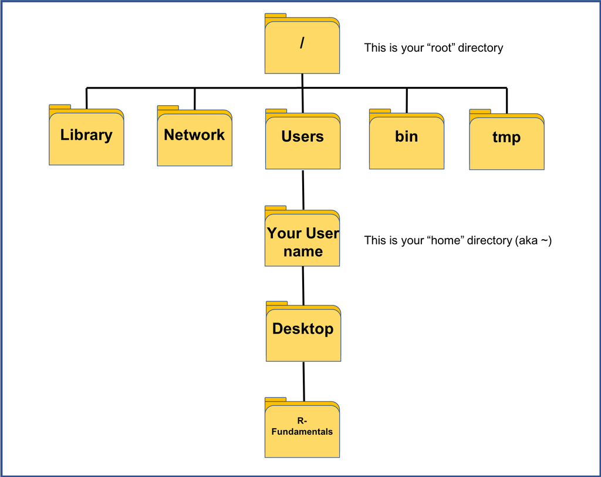

Navigate your file system until you can click on the **inbound** folder. You will notice that the actual data files are grayed-out because we are selecting the folder - not any of the files.

Load the `gapminder-FiveYearData.csv` dataset from the inbound folder inside the R-Fundamentals data directory:

```r
?read.csv
```

```r
gap = read.csv("/Users/evan.admin/Desktop/R-Fundamentals/inbound/gapminder-FiveYearData.csv",
                    header = TRUE,
                    stringsAsFactors = T,
                    na.strings = c("", " ", "999", "?", "NONE", "none"))
head(gap)
```

```
##       country year      pop continent lifeExp gdpPercap
## 1 Afghanistan 1952  8425333      Asia  28.801  779.4453
## 2 Afghanistan 1957  9240934      Asia  30.332  820.8530
## 3 Afghanistan 1962 10267083      Asia  31.997  853.1007
## 4 Afghanistan 1967 11537966      Asia  34.020  836.1971
## 5 Afghanistan 1972 13079460      Asia  36.088  739.9811
## 6 Afghanistan 1977 14880372      Asia  38.438  786.1134
```

```r
str(gap)
```

```
## 'data.frame':    1704 obs. of  6 variables:
##  $ country  : Factor w/ 142 levels "Afghanistan",..: 1 1 1 1 1 1 1 1 1 1 ...
##  $ year     : int  1952 1957 1962 1967 1972 1977 1982 1987 1992 1997 ...
##  $ pop      : num  8425333 9240934 10267083 11537966 13079460 ...
##  $ continent: Factor w/ 5 levels "Africa","Americas",..: 3 3 3 3 3 3 3 3 3 3 ...
##  $ lifeExp  : num  28.8 30.3 32 34 36.1 ...
##  $ gdpPercap: num  779 821 853 836 740 ...
```

```r
# View(gap)  # View entire dataset in a new tab!
```

# 2 Common `read.csv()` arguments

Notice that the `stringsAsFactors =` argument is set to `TRUE`. If set to `FALSE`, R will not automatically convert any **character** vectors to factor type. Here, we use the default sorts of alphabetical for text data and increasing order for numeric data. In real life data scenarios, you might want greater control over how factors are structured. Review Part1-6_data frames to see how to change factor level order.

`header = TRUE` will place the header row outside of the actual data; this is usually preferred so that column names display correctly. `header = FALSE` will turn your header row into the first row of actual data.

`na.strings = c("", " ", "999", "?", "NONE", "none")` indicates that any of the text inside of quotations should be automatically converted to `NA`. We do not have any here, so nothing is altered. However, remember this one as well!

# 3 **Challenge 1**

1. Load the mammals “sleep_VIM” dataset from the data folder using `read.csv()`. Save it in a variable named “Sleep_VIM”.

> NOTE: what is shown is another way to load datasets that are included in R and packages. Just type data() to see some of the many pre-built datasets in R!
2. Remember what `ls()` does? What does `dir()` do?

```r
data()
```

```r
# install.packages("VIM")
library(VIM)
data(sleep)
sleep_VIM = sleep

## YOUR CODE HERE
```

This dataset is part of the [VIM package](https://cran.r-project.org/web/packages/VIM/VIM.pdf). It looks at sleep patterns in various mammal species and contains missing (`NA`) values. Click [here](http://science.sciencemag.org/content/194/4266/732) to see the original research article.

> NOTE: you DO NOT want to load the Student’s Sleep Dataset from the “datasets” library. Your sleep dataset should have **62 rows and 10 columns**.

When dealing with Microsoft Excel files (.xlsx), you will find it more convenient to save them first as .csv files in Excel and then import them using `read.csv()`. However, you can also install the “foreign” package to load data from SPSS, Stata, Weka, Systat, Minitab, SAS, S, and MATLAB. See [this helpful documentation to learn more](https://cran.r-project.org/web/packages/rio/vignettes/rio.html).